# 데이터 과학 `tidyverse` 모형

통계검정 → LM/GLM

[Tidyverse Korea](https://www.facebook.com/groups/tidyverse/)

2020-05-02

# 1 모형과 가설검정 [^1] [^2]

모형으로 다양한 통계검정을 이해하게 되면 비모수 통계검정을 비롯하여 표본집단에 대한 구분부터 각각을 개별적으로 이해하고 암기할 필요가 없으며 단 하나의 수식 $y = \beta_0 + \beta_1 \times x$ 이라는 단순한 공식으로 상당수 통계검정을 처리할 수 있다. 예를 들어 상관분석, 일원 분산분석, t-검정, $\chi^2$-검정 등이 여기에 포함된다.

평균에 대한 가설검정은 다음 작업흐름도에 따라 어떻게 보면 기계적인 과정을 거쳐 판정에 이를 수 있다. 특히, [Common statistical tests are linear models (or: how to teach stats)](https://lindeloev.github.io/tests-as-linear/) 블로그에 관련 내용이 잘 정리되어 있다.

## 1.1 검정 작업흐름도

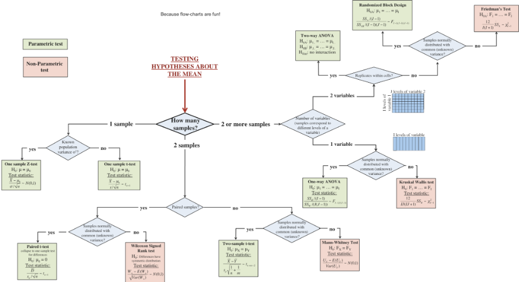

```r
webshot2::webshot("http://www.rebeccabarter.com/blog/2018-12-04_hypothesis_testing/",
                  selector = "#content > p:nth-child(3) > img",
                  "fig/hypothesis-testing.png")
```

## 1.2 선형모형과 통계검정

[figure not shown]

## 1.3 수식으로 일별하기

비모수 통계검정도 유사하게 확장이 가능하지만 우선 평균에 대한 통계검정을 수식으로 표현하면 다음과 같다.

- 일표본 `t-`검정: $y = \beta_0 \qquad \mathcal{H}_0: y = 0$
- 이표본 `t-`검정: $y = \beta_0 + \beta_1 x_1 \qquad \mathcal{H}_0: \beta_1 = 0$
- 다표본 분산분석: $y = \beta_0 + \beta_1 x_1 + \beta_2 x_2 + \beta_3 x_3 +... \qquad \mathcal{H}_0: y = \beta_0$

# 2 NBA 선수선발 데이터

실제 NBA 선수선발 데이터를 가지고 앞서 언급한 사례를 살펴보자. [NBA 선수선발 데이터](http://khannay.com/data/NBA_Draft_Data.csv)는 LeBron James 부터 선수선발 순위를 포함한 선수 역량과 관련된 정보가 정리되어 있다.

```r
library(tidyverse)

download.file(url="http://khannay.com/data/NBA_Draft_Data.csv", destfile = "data/NBA_Draft_Data.csv")

nba_df <- read_csv("data/NBA_Draft_Data.csv") %>%
  janitor::clean_names()

nba_df %>%
  arrange(-pts) %>%
  select(tm, player, pts, pick_number, everything()) %>%
  # sample_n(100) %>%
  DT::datatable()
```

|  | tm | player | pts | pick_number | x1 | age | pos | born | college | from | to | g | mp | trb | ast | stl | blk | fg_percent | x2p_percent | x3p_percent | ft_percent | ws | ws_48 | draft_year |
| --- | --- | --- | --- | --- | --- | --- | --- | --- | --- | --- | --- | --- | --- | --- | --- | --- | --- | --- | --- | --- | --- | --- | --- | --- |
| 1 | CLE | LeBron James\jamesle01 | 27.2 | 1 | 2 | 18.182 | F-G | us |  | 2004 | 2018 | 1091 | 38.9 | 7.3 | 7.1 | 1.6 | 0.8 | 0.503 | 0.545 | 0.344 | 0.74 | 5.73526115658573 | 0.24 | 2003 |
| 2 | SEA | Kevin Durant\duranke01 | 27.2 | 2 | 4 | 18.276 | F-G | us | University of Texas at Austin | 2008 | 2018 | 727 | 37.3 | 7.2 | 3.8 | 1.2 | 1.1 | 0.489 | 0.526 | 0.381 | 0.882 | 2.99019380711967 | 0.218 | 2007 |
| 3 | PHI | Allen Iverson\iversal01 | 26.7 | 1 | 121 | 21.025 | G | us | Georgetown University | 1997 | 2010 | 914 | 41.1 | 3.7 | 6.2 | 2.2 | 0.2 | 0.425 | 0.448 | 0.313 | 0.78 | 2.23900983648875 | 0.126 | 1996 |
| 4 | CHH | Kobe Bryant\bryanko01 | 25 | 13 | 28 | 17.312 | G-F | us |  | 1997 | 2016 | 1346 | 36.1 | 5.2 | 4.7 | 1.4 | 0.5 | 0.447 | 0.479 | 0.329 | 0.837 | 4.51729208486317 | 0.17 | 1996 |
| 5 | DEN | Carmelo Anthony\anthoca01 | 24.6 | 3 | 101 | 19.032 | F | us | Syracuse University | 2004 | 2018 | 1004 | 36.1 | 6.6 | 3.1 | 1 | 0.5 | 0.451 | 0.474 | 0.346 | 0.812 | 2.22973596030812 | 0.131 | 2003 |
| 6 | ORL | Shaquille O'Neal\onealsh01 | 23.7 | 1 | 7 | 20.115 | C | us | Louisiana State University | 1993 | 2011 | 1207 | 34.7 | 10.9 | 2.5 | 0.6 | 2.3 | 0.582 | 0.583 | 0.045 | 0.527 | 4.79550837028203 | 0.208 | 1992 |
| 7 | GSW | Stephen Curry\curryst01 | 22.9 | 7 | 8 | 21.108 | G | us | Davidson College | 2010 | 2018 | 597 | 34.6 | 4.4 | 6.8 | 1.8 | 0.2 | 0.476 | 0.51 | 0.435 | 0.903 | 1.91751546222696 | 0.206 | 2009 |
| 8 | MIA | Dwyane Wade\wadedw01 | 22.9 | 5 | 26 | 21.165 | G | us | Marquette University | 2004 | 2018 | 943 | 35 | 4.8 | 5.6 | 1.6 | 0.9 | 0.484 | 0.504 | 0.288 | 0.767 | 2.82944661998877 | 0.172 | 2003 |
| 9 | SEA | Russell Westbrook\westbru01 | 22.7 | 4 | 33 | 19.231 | G | us | University of California Los Angeles | 2009 | 2018 | 697 | 34.2 | 6.4 | 8 | 1.7 | 0.3 | 0.431 | 0.459 | 0.312 | 0.817 | 1.73203793861439 | 0.166 | 2008 |
| 10 | POR | Damian Lillard\lillada01 | 22.7 | 6 | 45 | 21.354 | G | us | Weber State University | 2013 | 2018 | 425 | 36.4 | 4.1 | 6.2 | 0.9 | 0.3 | 0.43 | 0.472 | 0.368 | 0.881 | 0.730459311106499 | 0.156 | 2012 |

[output cut: 727 more lines]

## 2.1 평균득점과 지명순서

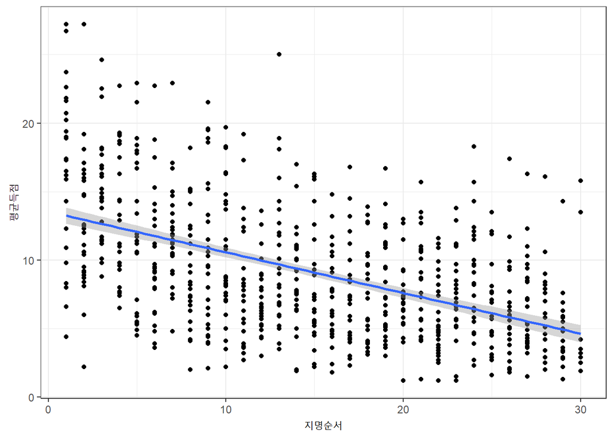

```r
nba_df %>%
  ggplot(aes(x=pick_number, y=pts)) +
    geom_point() +
    geom_smooth(method="lm") +
    theme_bw() +
    labs(x="지명순서", y="평균득점")
```

# 3 피어슨 상관관계

피어슨 상관관계를 모형으로 표현하면 다음과 같다.

$y = \beta_0 + \beta_1 \times x$ 선형모형에서 $\beta_1 = 0$ 인지 검정하는 것과 유사하다.

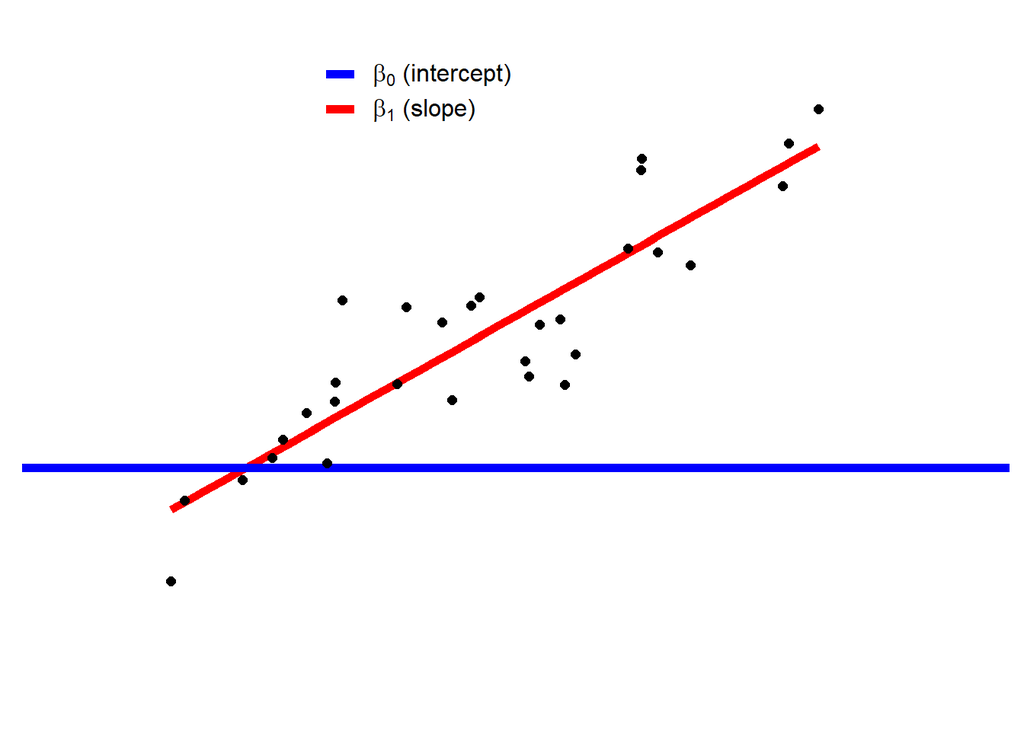

```r
# Fixed correlation
D_correlation <- data.frame(MASS::mvrnorm(30, mu = c(0.9, 0.9),
                            Sigma = matrix(c(1, 0.8, 1, 0.8), ncol = 2),
                            empirical = TRUE)) %>%
  as_tibble() # Correlated data

# Add labels (for next plot)
D_correlation <- D_correlation %>%
  mutate(label_num = sprintf('(%.1f,%.1f)', X1, X2),
         label_rank = sprintf('(%i,%i)', rank(X1), rank(X2)))

# Plot it
fit <- lm(I(X2 * 0.5 + 0.4) ~ I(X1 * 0.5 + 0.2), D_correlation)
intercept_pearson <- coefficients(fit)[1]

P_pearson <- ggplot(D_correlation, aes(x=X1*0.5+0.2, y=X2*0.5+0.4)) +
  geom_point() +
  geom_smooth(method=lm, se=FALSE, lwd=2, aes(colour='beta_1')) +
  geom_segment(x=-100, xend=100,
               y=intercept_pearson, yend=intercept_pearson,
               lwd=2, aes(color="beta_0")) +
  scale_color_manual(name=NULL, values=c("blue", "red"), labels=c(bquote(beta[0]*" (intercept)"), bquote(beta[1]*" (slope)")))

theme_axis(P_pearson, legend.position = c(0.4, 0.9))
```

앞선 이론적인 배경을 바탕으로 `MP: Minutes Played`와 `PTS: Points`를 산점도로 파악하고 이에 대한 상관관계를 통계검정과 선형모형으로 비교해보자. 즉, 인과관계는 모르겠지만 `MP`와 `PTS`간의 상관관계는 존재하는 파악하고자 한다.

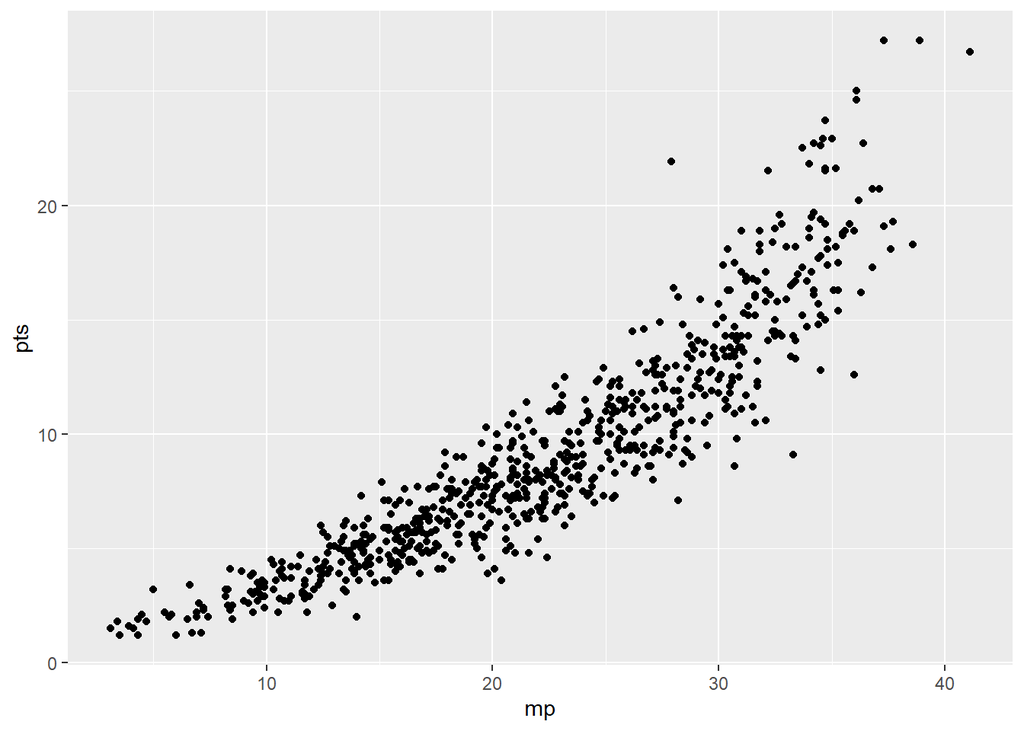

```r
nba_df %>%
  ggplot(aes(x=mp, y=pts)) +
    geom_point()
```

$$\hat {\beta} = {\rm cor}(Y_i, X_i) \cdot \frac{ {\rm SD}(Y_i) }{ {\rm SD}(X_i) }$$

${\rm SD}(Y_i) = {\rm SD}(X_i)$ 동일한 경우에만 $\hat{\beta}$이 상관계수와 동일한 관계를 갖는 점을 명심하면 `cor.test()` 내장함수로 구현된 상관계수 통계검정과 `glm()` 선형모형을 비교해보면 약간의 차이는 있지만 `t` 통계량은 물론 `p-`값도 유사함을 발견할 수 있다.

```r
cor.test(nba_df$mp, nba_df$pts, method = "pearson")
```

```
    Pearson's product-moment correlation

data:  nba_df$mp and nba_df$pts
t = 59.585, df = 735, p-value < 2.2e-16
alternative hypothesis: true correlation is not equal to 0
95 percent confidence interval:
 0.8969551 0.9218351
sample estimates:
      cor
0.9102128
```

```r
pts_cor_lm <- lm(pts ~ 1 + mp, data = nba_df)
broom::tidy(pts_cor_lm)
```

```
# A tibble: 2 x 5
  term        estimate std.error statistic   p.value
  <chr>          <dbl>     <dbl>     <dbl>     <dbl>
1 (Intercept)   -3.43    0.225       -15.3 5.83e- 46
2 mp             0.569   0.00955      59.6 1.30e-283
```

```r
pts_cor_lm <- lm(scale(pts) ~ 1 + scale(mp), data = nba_df)
broom::tidy(pts_cor_lm)
```

```
# A tibble: 2 x 5
  term         estimate std.error statistic   p.value
  <chr>           <dbl>     <dbl>     <dbl>     <dbl>
1 (Intercept) -1.12e-17    0.0153 -7.35e-16 1.00e+  0
2 scale(mp)    9.10e- 1    0.0153  5.96e+ 1 1.30e-283
```

# 4 일표본 `t`-검정

`GLM` 모형과 `t-`검정을 비교해보자. 즉, 수식은 다음과 같고 의미하는 바는 평균이 0과 다름이 있느냐를 따지게 된다. $y = \beta_0 + \beta_1*x$에서 $x=0$이라 절편만 검정하게 된다.

$$y = \beta_0 \qquad \mathcal{H}_0: \beta_0 = 0$$

**`t-`검정**

```r
one_sample_ttest <- t.test(nba_df$pts, mu =0)

broom::tidy(one_sample_ttest)
```

```
# A tibble: 1 x 8
  estimate statistic   p.value parameter conf.low conf.high method   alternative
     <dbl>     <dbl>     <dbl>     <dbl>    <dbl>     <dbl> <chr>    <chr>
1     9.19      50.5 1.90e-241       736     8.83      9.54 One Sam~ two.sided
```

**선형 모형**

```r
one_sample_lm <- lm(pts ~ 1, data=nba_df)

broom::tidy(one_sample_lm)
```

```
# A tibble: 1 x 5
  term        estimate std.error statistic   p.value
  <chr>          <dbl>     <dbl>     <dbl>     <dbl>
1 (Intercept)     9.19     0.182      50.5 1.90e-241
```

## 4.1 대응표본 `t`-검정

반복측정, 예를 들어 동일한 선수가 동일한 조건에서 약물복용 이후 약물복용 효과를 측정하고자 하는 경우 대응표본 `t`-검정(Paired t-test)이 되고 수식으로 다음과 같이 표현된다.

$y_2-y_1 = \beta_0 \qquad \mathcal{H}_0: \beta_0 = 0$

먼저 앞선 경우와 비교하기 위해서 시각화를 한다. `sleep` 데이터는 최면약(soporific drug)으로 통제집단과 비교하여 효과가 있는지를 10명의 환자에게 투여하여 비교해서 자체 내장된 데이터셋이다.

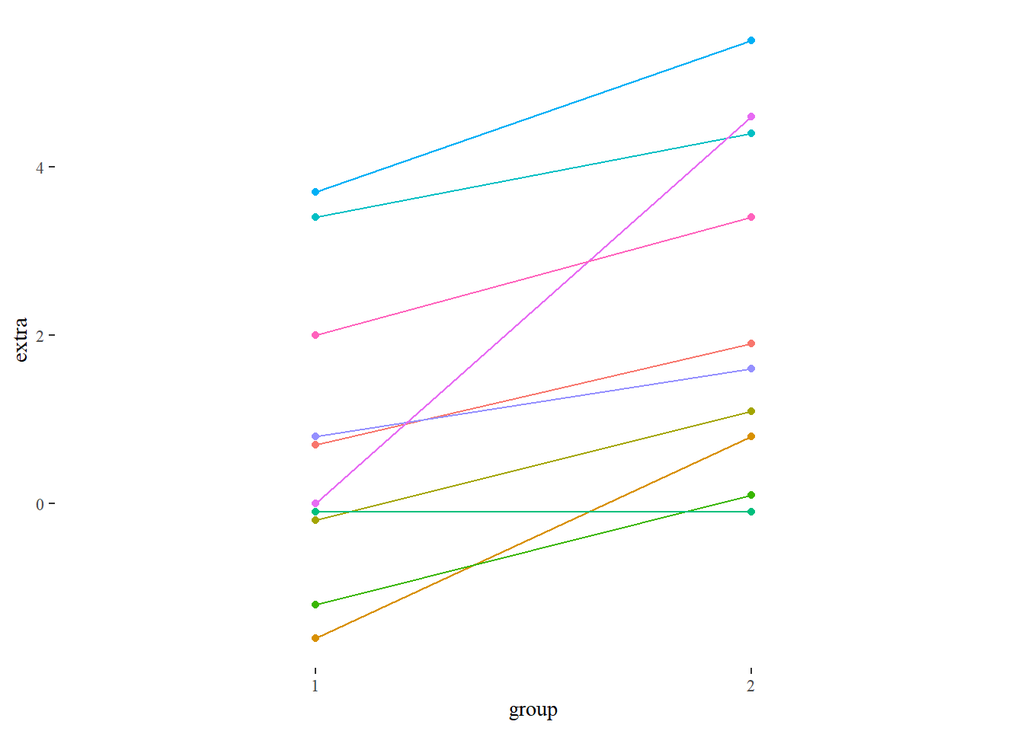

```r
library(ggthemes)
sleep %>%
  ggplot(aes(x = group, y = extra, color=ID)) +
    geom_point(show.legend = FALSE) +
    geom_line(aes(group = ID), show.legend = FALSE) +
    theme_tufte()
```

```r
sleep_df <- sleep %>%
  spread(group, extra)
```

**대응표본 `t-`검정**

```r
t.test(sleep_df$`1`, sleep_df$`2`, paired=TRUE) %>%
  broom::tidy(.)
```

```
# A tibble: 1 x 8
  estimate statistic p.value parameter conf.low conf.high method     alternative
     <dbl>     <dbl>   <dbl>     <dbl>    <dbl>     <dbl> <chr>      <chr>
1    -1.58     -4.06 0.00283         9    -2.46    -0.700 Paired t-~ two.sided
```

**통계모형**

```r
lm(sleep_df$`1` - sleep_df$`2` ~ 1) %>%
  broom::tidy(.)
```

```
# A tibble: 1 x 5
  term        estimate std.error statistic p.value
  <chr>          <dbl>     <dbl>     <dbl>   <dbl>
1 (Intercept)    -1.58     0.389     -4.06 0.00283
```

# 5 독립 두 표본 `t`-검정

독립된 두 표본(two-sample) 평균검정은 선형모형으로 다음과 같이 나타낼 수 있다. 여기서 $x_i$는 0 혹은 1 을 갖는 범주형 변수로 두 표본을 표식하는데 사용된다. 이를 확장하면 다집단에 대한 평균검정도 할 수 있는데 이 경우 ANOVA로 확장된다.

$y_i = \beta_0 + \beta_1 x_i \qquad \mathcal{H}_0: \beta_1 = 0$

이를 위해서 선수선발 16 이상은 하위, 1 - 15 순위는 상위권으로 두어 두개의 집단으로 나눠 평균득점에 차이가 있는 살펴보자.

```r
nba_df <- nba_df %>%
  mutate(pick_binary = if_else(pick_number > 15, "하위", "상위")) %>%
  mutate(pick_binary = factor(pick_binary, levels = c("하위", "상위")))
```

**독립표본 `t-`검정**

```r
t.test(pts ~ pick_binary, data = nba_df, var.equal = TRUE) %>%
  broom::tidy(.)
```

```
# A tibble: 1 x 9
  estimate1 estimate2 statistic  p.value parameter conf.low conf.high method
      <dbl>     <dbl>     <dbl>    <dbl>     <dbl>    <dbl>     <dbl> <chr>
1      7.04      11.0     -12.0 2.00e-30       735    -4.66     -3.35 " Two~
# ... with 1 more variable: alternative <chr>
```

**범주를 갖는 회귀모형**

```r
lm(pts ~ pick_binary, data=nba_df) %>%
  broom::tidy(.)
```

```
# A tibble: 2 x 5
  term            estimate std.error statistic   p.value
  <chr>              <dbl>     <dbl>     <dbl>     <dbl>
1 (Intercept)         7.04     0.244      28.8 7.70e-123
2 pick_binary상위     4.00     0.334      12.0 2.00e- 30
```

# 6 분산분석(ANOVA)

$x_i$는 ($x=0$ or $x=1$)을 갖는 지시변수로, 다른 모든 변수가 $x_i=0$이 될 때 $x_i=1$는 1을 갖는다. 수식으로는 다음과 같이 표현되고 그룹간에 평균적인 차이가 있는지 검정하는 것으로 집단이 2개이상될 때 사용한다.

$y = \beta_0 + \beta_1 x_1 + \beta_2 x_2 + \beta_3 x_3 +... \qquad \mathcal{H}_0: y = \beta_0$

2표본 이상 다집단에 대한 평균에 대한 차이를 분석하기 위해서 다음과 같이 팀을 3개 뽑아내서 새로운 데이터프레임으로 준비를 한다. type-II sum of square 혹은 type-III sum of square 에 따라 차이가 있기는 하지만 `glm` 모형으로 비교를 할 수 있다.

```r
anova_df <- nba_df %>%
  filter(tm %in% c("BOS", "MIN", "CHI"))
```

**ANOVA 분산분석**

```r
car::Anova(aov(pts ~ tm, anova_df), type='II') %>%
  broom::tidy(.)
```

```
# A tibble: 2 x 5
  term       sumsq    df statistic p.value
  <chr>      <dbl> <dbl>     <dbl>   <dbl>
1 tm          77.3     2      1.59   0.210
2 Residuals 2142.     88     NA     NA
```

**가변수 회귀모형**

```r
glm(pts ~ tm, data=anova_df) %>%
  broom::glance(.) %>%
  mutate(sumsq = null.deviance - deviance) %>%
  select(null.deviance, sumsq, deviance, everything())
```

```
# A tibble: 1 x 8
  null.deviance sumsq deviance df.null logLik   AIC   BIC df.residual
          <dbl> <dbl>    <dbl>   <int>  <dbl> <dbl> <dbl>       <int>
1         2219.  77.3    2142.      90  -273.  554.  564.          88
```

# 7 교호작용(interaction)

앞선 일원분산분석을 확장하여 이원분산분석도 가능한데 이런 경우 교호작용을 파악하는 것이 중요하다. 이를 위해서 두가지 모형에 대해서 비교를 해보자. 수식으로는 다음과 같고 두가지 요인 하나는 팀(`tm`), 다른 하나는 상위 혹은 하위 선수선발 가변수(`pick_binary`)로 두 변수간에 상승 혹은 역효과가 평균득점에 효과를 나타내는지 살펴보자.

$y = \beta_0 + \beta_1 X_1 + \beta_2 X_2 + \beta_3 X_1 X_2 \qquad \mathcal{H}_0: \beta_3 = 0$

**교호작용 검정**

```r
car::Anova(aov(pts ~ pick_binary * tm, anova_df))  %>%
  broom::tidy(.)
```

```
# A tibble: 4 x 5
  term             sumsq    df statistic       p.value
  <chr>            <dbl> <dbl>     <dbl>         <dbl>
1 pick_binary     614.       1   34.2     0.0000000902
2 tm               20.4      2    0.568   0.569
3 pick_binary:tm    1.76     2    0.0490  0.952
4 Residuals      1526.      85   NA      NA
```

**interaction 항을 갖는 회귀모형**

```r
anova_null = lm(pts ~ 1 + tm + pick_binary, anova_df)
anova_full = lm(pts ~ 1 + tm + pick_binary + tm:pick_binary, anova_df)

anova(anova_null, anova_full) %>%
  broom::tidy(.)
```

```
# A tibble: 2 x 6
  res.df   rss    df sumsq statistic p.value
   <dbl> <dbl> <dbl> <dbl>     <dbl>   <dbl>
1     87 1528.    NA NA      NA       NA
2     85 1526.     2  1.76    0.0490   0.952
```

# 8 ANCOVA

평균득점같은 연속형 변수에 대한 검정을 할 때 다른 요인을 고려한 후에 특정 요인에 대한 효과를 살펴보고자 하는 경우가 상식적이다. 이런 경우 나이(`age`)를 고려한 후에 다양한 효과를 파악하는 것도 가능하다. $x_i$는 앞서와 같은 지시변수로 0 혹은 1을 갖는다는 점에서 동일하다.

$y = \beta_0 + \beta_1 x_1 + \beta_2 x_2 + ... + \beta_3 age$

**Ancova 통계검정**

```r
car::Anova(aov(pts ~ pick_binary + age, anova_df), type = 'III') %>%
  broom::tidy(.)
```

```
# A tibble: 4 x 5
  term        sumsq    df statistic      p.value
  <chr>       <dbl> <dbl>     <dbl>        <dbl>
1 (Intercept)  273.     1      17.3  0.0000735
2 pick_binary  512.     1      32.5  0.000000156
3 age          162.     1      10.2  0.00191
4 Residuals   1387.    88      NA   NA
```

**Ancova GLM**

```r
ancova_full_lm <- lm(pts ~ 1 + pick_binary + age, data=anova_df)
ancova_reduced_lm <- lm(pts ~ 1 + pick_binary, data=anova_df)

anova(ancova_full_lm, ancova_reduced_lm, test="LRT") %>%
  broom::tidy(.)
```

```
# A tibble: 2 x 5
  res.df   rss    df sumsq  p.value
   <dbl> <dbl> <dbl> <dbl>    <dbl>
1     88 1387.    NA   NA  NA
2     89 1549.    -1 -162.  0.00137
```

# 9 범주형 검정 [^3]

[^1]: [Kevin Hannay (Jan 13 2020), “Everything is a Regression:In search of unifying paradigms in statistics”](https://towardsdatascience.com/everything-is-just-a-regression-5a3bf22c459c)
[^2]: [Rebecca Barter (December 4, 2018), “Which hypothesis test should I use? A flowchart: A flowchart to decide what hypothesis test to use.”](http://www.rebeccabarter.com/blog/2018-12-04_hypothesis_testing/)
[^3]: [Phillip M. Alday (May 2018), “Explicit GLM(M) Equivalents for Standard Tests”](https://rpubs.com/palday/glm-test)